# HW05 Part 2: Importing

Donovan Kleinberg

28 December 2018

## Limpets

```r
library(tidyverse)
file_path <- "C:\\Misc. Files\\BI485 Folder\\Kleinberg_Donovan\\data"
limpet <- read_csv(file.path(file_path, "limpets.csv"))
```

```r
limpet
```

| Length | Site | Protected |
| --- | --- | --- |
| 10 | PBL | Yes |
| 10 | PBL | Yes |
| 10 | PBL | Yes |
| 15 | PBL | Yes |
| 15 | PBL | Yes |
| 15 | PBL | Yes |
| 15 | PBL | Yes |
| 15 | PBL | Yes |
| 15 | PBL | Yes |
| 15 | PBL | Yes |

[output cut: 990 more lines]

Chunk for column identification.

```r
read_csv(file.path(file_path, "limpets.csv"), col_types = c("ncc"))
```

| Length | Site | Protected |
| --- | --- | --- |
| 10 | PBL | Yes |
| 10 | PBL | Yes |
| 10 | PBL | Yes |
| 15 | PBL | Yes |
| 15 | PBL | Yes |
| 15 | PBL | Yes |
| 15 | PBL | Yes |
| 15 | PBL | Yes |
| 15 | PBL | Yes |
| 15 | PBL | Yes |

[output cut: 990 more lines]

Chunk for ordering site

```r
Ordered_sites <- factor(limpet, levels = c("PBL", "KNRM", "VBG", "WP", "PF", "DP", "SIO", "CTZ1", "CTZ2", "CNM"), ordered = TRUE)
```

Chunk for boxplot

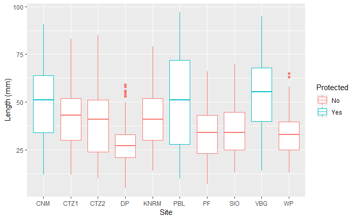

```r
ggplot(data = limpet, mapping = aes(x = Site, y = Length)) +
  geom_boxplot(mapping = aes(color = Protected)) +
    xlab("Site") + ylab("Length (mm)")
```

Description for Boxplot: There are 2 sites with outliers, DP and WP. The protected sites all seem to have longer limpets than non protected sites.

## Terns

```r
file_path <- "C:\\Misc. Files\\BI485 Folder\\Kleinberg_Donovan\\data"
tern <- read.delim(file.path(file_path, "roseate_terns.txt"))
tern
```

| year | AR | AL | AC | BR | BL | BC | JR | JL | JC |
| --- | --- | --- | --- | --- | --- | --- | --- | --- | --- |
| 1992 | 378 | 76 | 29 | 378 | NA | 29 | 651 | NA | 35 |
| 1993 | 427 | 76 | 28 | 427 | 76 | 28 | 717 | 50 | 30 |
| 1994 | 394 | 140 | 35 | 394 | NA | 35 | 553 | NA | 35 |
| 1995 | 554 | 62 | 36 | 554 | 62 | 36 | 697 | 96 | 36 |
| 1996 | 563 | 124 | 24 | 563 | 124 | 24 | 770 | 106 | 24 |
| 1997 | 602 | 48 | 25 | 34 | 48 | 25 | 35 | 52 | 17 |
| 1998 | 578 | 80 | 29 | 79 | 9 | 29 | 69 | 13 | 33 |
| 1999 | 611 | 116 | 34 | 125 | 14 | 34 | 161 | 20 | 33 |
| 2000 | 618 | NA | 34 | 174 | NA | 34 | 265 | NA | 33 |
| 2001 | 605 | 46 | 42 | 80 | 46 | 42 | 118 | 0 | 55 |

[output cut: 15 more lines]

Tidying the data

```r
tidy_tern <- tern %>%
  gather("AR", "AL", "AC", "BR", "BL", "BC", "JR", "JL", "JC", key = "Site", value = "Individuals")
tidy_tern
```

| year | Site | Individuals |
| --- | --- | --- |
| 1992 | AR | 378 |
| 1993 | AR | 427 |
| 1994 | AR | 394 |
| 1995 | AR | 554 |
| 1996 | AR | 563 |
| 1997 | AR | 602 |
| 1998 | AR | 578 |
| 1999 | AR | 611 |
| 2000 | AR | 618 |
| 2001 | AR | 605 |

[output cut: 215 more lines]

Filtering out NA data

```r
filter(tidy_tern, is.na(Individuals) == FALSE)
```

| year | Site | Individuals |
| --- | --- | --- |
| 1992 | AR | 378 |
| 1993 | AR | 427 |
| 1994 | AR | 394 |
| 1995 | AR | 554 |
| 1996 | AR | 563 |
| 1997 | AR | 602 |
| 1998 | AR | 578 |
| 1999 | AR | 611 |
| 2000 | AR | 618 |
| 2001 | AR | 605 |

[output cut: 204 more lines]

Lineplot of Tern data

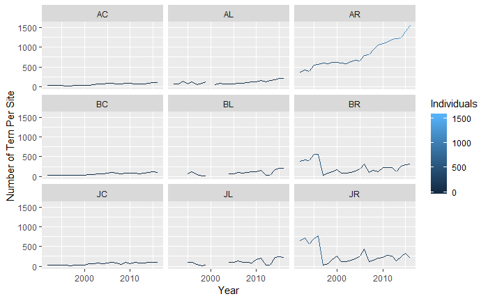

```r
ggplot(data = tidy_tern, mapping = aes(x = year, y = Individuals)) +
  geom_line(mapping = aes(color = Individuals)) +
  xlab("Year") + ylab("Number of Tern Per Site") +
    facet_wrap(~ Site, nrow = 3)
```

Description for line plot: The site labelled AR has shown an obvious increase in population size, sites BR and JR meanwhile have shown obvious decreases in population size. Gaps in the data symbolize NA data due to no survey during that period.

## Darters

```r
file_path <- "C:\\Misc. Files\\BI485 Folder\\Kleinberg_Donovan\\data"
darters <- read.delim(file.path(file_path, "darter.txt"))
darters
```

| X..1.3.specimen.id |
| --- |
| # 4-14 species |
| # 15 riffle: 1 = upstream riffle, 2 = downstream riffle |
| # 16 age in year |
| # 17 sex |
| # 18-20 length in centimeters |
| # 21-24 depth in centimeters |
| # 25-28 velocity in meters per second |
| # 29-32 temperature Celsius |
| # 33-35 majsub proportion of major substrate type |
| # 36-38 minsub proportion of minor substrate type |

[output cut: 129 more lines]

```r
Column_start <- c(1, 4, 15, 16, 17, 18, 21, 25, 29, 33, 36, 39, 40)
Column_stop <- c(3, 14, 15, 16, 17, 20, 24, 28, 32, 35, 38, 40, 41)
names <- c("specimen id", "species", "riffle", "age", "sex", "length", "depth", "velocity", "temperature", "majsub", "minsub", "majtype", "mintype")
tidy_darters <- read_fwf(file.path(file_path, "darter.txt"), fwf_positions(Column_start, Column_stop, col_names = names), skip = 15)
tidy_darters
```

| specimen id | species | riffle | age | sex | length | depth | velocity | temperature | majsub | minsub | majtype | mintype |
| --- | --- | --- | --- | --- | --- | --- | --- | --- | --- | --- | --- | --- |
| 3 | blennioides | 1 | 1 | f | 3.1 | 8.0 | 0.39 | 30.2 | 0.6 | 0.4 | lg | gs |
| 4 | blennioides | 1 | 1 | f | 3.3 | 59.0 | 0.34 | 25.4 | 0.5 | 0.5 | sg | gs |
| 5 | blennioides | 1 | 1 | m | 3.5 | 27.0 | 0.34 | 28.0 | 0.8 | 0.2 | lg | gc |
| 6 | blennioides | 1 | 1 | m | 3.6 | 7.0 | 0.36 | 24.0 | 0.6 | 0.4 | sg | gl |
| 7 | blennioides | 1 | 1 | m | 3.7 | 13.5 | 0.61 | 29.4 | 0.6 | 0.4 | lg | gs |
| 8 | blennioides | 1 | 1 | m | 3.7 | 27.0 | 0.34 | 28.0 | 0.5 | 0.5 | lg | gs |
| 9 | blennioides | 1 | 1 | f | 3.8 | 11.5 | 0.34 | 30.0 | 0.6 | 0.4 | lg | gs |
| 10 | blennioides | 1 | 1 | m | 3.8 | 12.0 | 0.39 | 29.8 | 0.6 | 0.4 | lg | gs |
| 30 | caeruleum | 1 | 0 | f | 2.2 | 67.0 | 0.43 | 28.1 | 1.0 | 0.0 | lg | gz |
| 31 | caeruleum | 1 | 0 | m | 2.4 | 3.2 | 0.43 | 30.8 | 0.8 | 0.2 | lg | gs |

[output cut: 115 more lines]

Unordered and Ordered Factors

```r
riff <- c("1", "2")
riffle <- factor(riff)
major <- c("s", "fg", "sg", "lg", "c")
major_type <- factor(major, ordered = TRUE, levels = c("s", "fg", "sg", "lg", "c"))
```

The Pipe

```r
good_darters <- tidy_darters %>%
  filter(!species %in% c("zonale", "tetrazonum"))
```

```r
gooder_darters <- subset(good_darters, select = -c(mintype,minsub) )
gooder_darters
```

| specimen id | species | riffle | age | sex | length | depth | velocity | temperature | majsub | majtype |
| --- | --- | --- | --- | --- | --- | --- | --- | --- | --- | --- |
| 3 | blennioides | 1 | 1 | f | 3.1 | 8.0 | 0.39 | 30.2 | 0.6 | lg |
| 4 | blennioides | 1 | 1 | f | 3.3 | 59.0 | 0.34 | 25.4 | 0.5 | sg |
| 5 | blennioides | 1 | 1 | m | 3.5 | 27.0 | 0.34 | 28.0 | 0.8 | lg |
| 6 | blennioides | 1 | 1 | m | 3.6 | 7.0 | 0.36 | 24.0 | 0.6 | sg |
| 7 | blennioides | 1 | 1 | m | 3.7 | 13.5 | 0.61 | 29.4 | 0.6 | lg |
| 8 | blennioides | 1 | 1 | m | 3.7 | 27.0 | 0.34 | 28.0 | 0.5 | lg |
| 9 | blennioides | 1 | 1 | f | 3.8 | 11.5 | 0.34 | 30.0 | 0.6 | lg |
| 10 | blennioides | 1 | 1 | m | 3.8 | 12.0 | 0.39 | 29.8 | 0.6 | lg |
| 30 | caeruleum | 1 | 0 | f | 2.2 | 67.0 | 0.43 | 28.1 | 1.0 | lg |
| 31 | caeruleum | 1 | 0 | m | 2.4 | 3.2 | 0.43 | 30.8 | 0.8 | lg |

[output cut: 107 more lines]

```r
colnames(gooder_darters)[colnames(gooder_darters)=="majsub"] <- "major_substrate"
colnames(gooder_darters)[colnames(gooder_darters)=="majtype"] <- "major_type"
gooder_darters
```

| specimen id | species | riffle | age | sex | length | depth | velocity | temperature | major_substrate | major_type |
| --- | --- | --- | --- | --- | --- | --- | --- | --- | --- | --- |
| 3 | blennioides | 1 | 1 | f | 3.1 | 8.0 | 0.39 | 30.2 | 0.6 | lg |
| 4 | blennioides | 1 | 1 | f | 3.3 | 59.0 | 0.34 | 25.4 | 0.5 | sg |
| 5 | blennioides | 1 | 1 | m | 3.5 | 27.0 | 0.34 | 28.0 | 0.8 | lg |
| 6 | blennioides | 1 | 1 | m | 3.6 | 7.0 | 0.36 | 24.0 | 0.6 | sg |
| 7 | blennioides | 1 | 1 | m | 3.7 | 13.5 | 0.61 | 29.4 | 0.6 | lg |
| 8 | blennioides | 1 | 1 | m | 3.7 | 27.0 | 0.34 | 28.0 | 0.5 | lg |
| 9 | blennioides | 1 | 1 | f | 3.8 | 11.5 | 0.34 | 30.0 | 0.6 | lg |
| 10 | blennioides | 1 | 1 | m | 3.8 | 12.0 | 0.39 | 29.8 | 0.6 | lg |
| 30 | caeruleum | 1 | 0 | f | 2.2 | 67.0 | 0.43 | 28.1 | 1.0 | lg |
| 31 | caeruleum | 1 | 0 | m | 2.4 | 3.2 | 0.43 | 30.8 | 0.8 | lg |

[output cut: 107 more lines]

```r
gooder_darters %>% arrange(-desc(`specimen id`))
```

| specimen id | species | riffle | age | sex | length | depth | velocity | temperature | major_substrate | major_type |
| --- | --- | --- | --- | --- | --- | --- | --- | --- | --- | --- |
| 3 | blennioides | 1 | 1 | f | 3.1 | 8.0 | 0.39 | 30.2 | 0.6 | lg |
| 4 | blennioides | 1 | 1 | f | 3.3 | 59.0 | 0.34 | 25.4 | 0.5 | sg |
| 5 | blennioides | 1 | 1 | m | 3.5 | 27.0 | 0.34 | 28.0 | 0.8 | lg |
| 6 | blennioides | 1 | 1 | m | 3.6 | 7.0 | 0.36 | 24.0 | 0.6 | sg |
| 7 | blennioides | 1 | 1 | m | 3.7 | 13.5 | 0.61 | 29.4 | 0.6 | lg |
| 8 | blennioides | 1 | 1 | m | 3.7 | 27.0 | 0.34 | 28.0 | 0.5 | lg |
| 9 | blennioides | 1 | 1 | f | 3.8 | 11.5 | 0.34 | 30.0 | 0.6 | lg |
| 10 | blennioides | 1 | 1 | m | 3.8 | 12.0 | 0.39 | 29.8 | 0.6 | lg |
| 11 | blennioides | 2 | 0 | f | 2.7 | 13.0 | 0.34 | 22.2 | 0.5 | lg |
| 12 | blennioides | 2 | 1 | m | 3.0 | 15.3 | 0.39 | 27.4 | 0.6 | sg |

[output cut: 107 more lines]

Plot 1

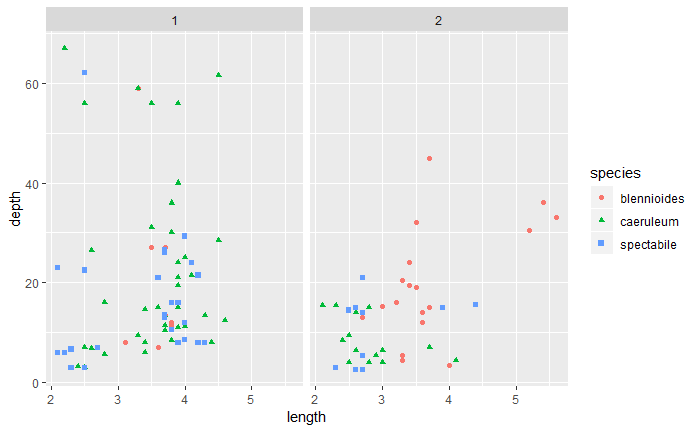

```r
ggplot(data = gooder_darters, mapping = aes(x = length, y = depth)) +
  geom_point(mapping = aes(color = species, shape = species)) +
  facet_wrap(~ riffle)
```

Plot 2

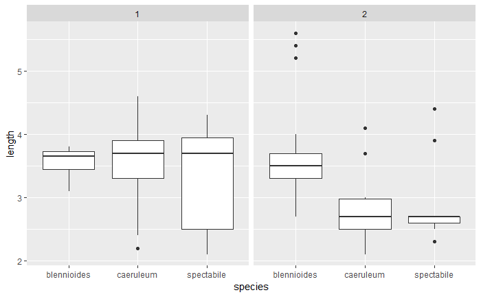

```r
ggplot(data = gooder_darters, mapping = aes(x = species, y = length)) +
  geom_boxplot() +
  facet_wrap(~ riffle)
```

Description of plot 2: Riffle 2 has by far the greater number of outliers.

Plot 3

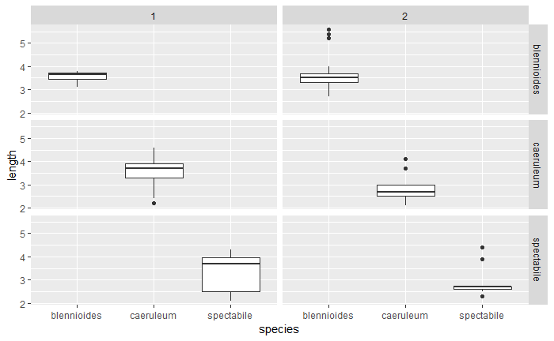

```r
ggplot(data = gooder_darters, mapping = aes(x = species, y = length)) +
  geom_boxplot() +
  facet_grid(species ~ riffle)
```

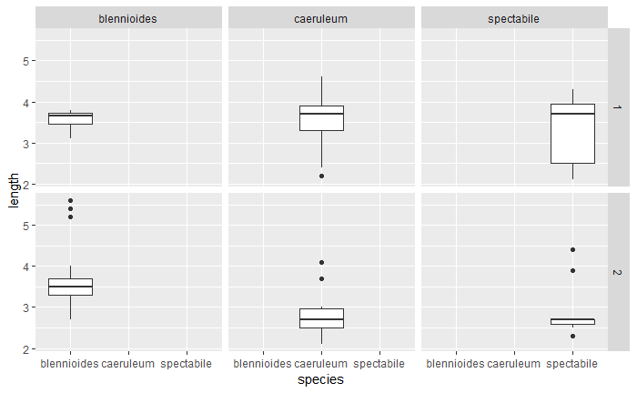

```r
ggplot(data = gooder_darters, mapping = aes(x = species, y = length)) +
  geom_boxplot() +
  facet_grid(riffle ~ species)
```

Description of plot 3: Switching species and riffle results in a graph that is less pleasing to read and one that doesn’t appear to function properly.

## Abalone

Chunk 1

```r
file_path <- "C:\\Misc. Files\\BI485 Folder\\Kleinberg_Donovan\\data"
abalone <-  read_csv(file.path(file_path, "abalone.csv"))
abalone
```

| X1 | Type | LongestShell | Diameter | Height | WholeWeight | ShuckedWeight | VisceraWeight | ShellWeight | Rings |
| --- | --- | --- | --- | --- | --- | --- | --- | --- | --- |
| 1 | M | 0.455 | 0.365 | 0.095 | 0.5140 | 0.2245 | 0.1010 | 0.1500 | 15 |
| 2 | M | 0.350 | 0.265 | 0.090 | 0.2255 | 0.0995 | 0.0485 | 0.0700 | 7 |
| 3 | F | 0.530 | 0.420 | 0.135 | 0.6770 | 0.2565 | 0.1415 | 0.2100 | 9 |
| 4 | M | 0.440 | 0.365 | 0.125 | 0.5160 | 0.2155 | 0.1140 | 0.1550 | 10 |
| 5 | I | 0.330 | 0.255 | 0.080 | 0.2050 | 0.0895 | 0.0395 | 0.0550 | 7 |
| 6 | I | 0.425 | 0.300 | 0.095 | 0.3515 | 0.1410 | 0.0775 | 0.1200 | 8 |
| 7 | F | 0.530 | 0.415 | 0.150 | 0.7775 | 0.2370 | 0.1415 | 0.3300 | 20 |
| 8 | F | 0.545 | 0.425 | 0.125 | 0.7680 | 0.2940 | 0.1495 | 0.2600 | 16 |
| 9 | M | 0.475 | 0.370 | 0.125 | 0.5095 | 0.2165 | 0.1125 | 0.1650 | 9 |
| 10 | F | 0.550 | 0.440 | 0.150 | 0.8945 | 0.3145 | 0.1510 | 0.3200 | 19 |

[output cut: 990 more lines]

```r
abalone_no_first <- abalone[-c(1)]
abalone_no_first
```

| Type | LongestShell | Diameter | Height | WholeWeight | ShuckedWeight | VisceraWeight | ShellWeight | Rings |
| --- | --- | --- | --- | --- | --- | --- | --- | --- |
| M | 0.455 | 0.365 | 0.095 | 0.5140 | 0.2245 | 0.1010 | 0.1500 | 15 |
| M | 0.350 | 0.265 | 0.090 | 0.2255 | 0.0995 | 0.0485 | 0.0700 | 7 |
| F | 0.530 | 0.420 | 0.135 | 0.6770 | 0.2565 | 0.1415 | 0.2100 | 9 |
| M | 0.440 | 0.365 | 0.125 | 0.5160 | 0.2155 | 0.1140 | 0.1550 | 10 |
| I | 0.330 | 0.255 | 0.080 | 0.2050 | 0.0895 | 0.0395 | 0.0550 | 7 |
| I | 0.425 | 0.300 | 0.095 | 0.3515 | 0.1410 | 0.0775 | 0.1200 | 8 |
| F | 0.530 | 0.415 | 0.150 | 0.7775 | 0.2370 | 0.1415 | 0.3300 | 20 |
| F | 0.545 | 0.425 | 0.125 | 0.7680 | 0.2940 | 0.1495 | 0.2600 | 16 |
| M | 0.475 | 0.370 | 0.125 | 0.5095 | 0.2165 | 0.1125 | 0.1650 | 9 |
| F | 0.550 | 0.440 | 0.150 | 0.8945 | 0.3145 | 0.1510 | 0.3200 | 19 |

[output cut: 990 more lines]

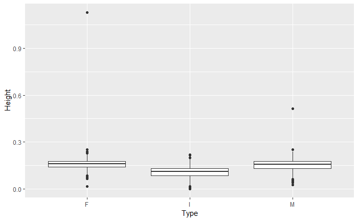

```r
ggplot(data = abalone_no_first, mapping = aes(x = Type, y = Height)) +
  geom_boxplot()
```

Chunk 2

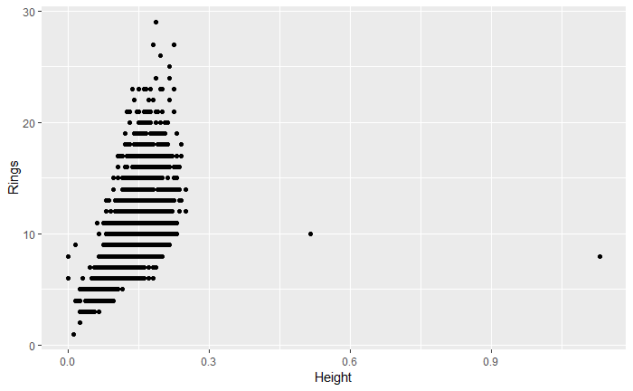

```r
ggplot(data = abalone_no_first, mapping = aes(x = Height, y = Rings)) +
  geom_point()
```

Description for chunk 2: It would appear that the outliers are only around 7-10 years old and are not extremely old.

Chunk 3

```r
abalone_error <- filter(abalone_no_first, Height < 0.3)
abalone_ordered <- abalone_error$Type <- factor(abalone_error$Type, levels = c("I", "F", "M"), ordered = TRUE)
abalone_ordered
```

[output not shown]

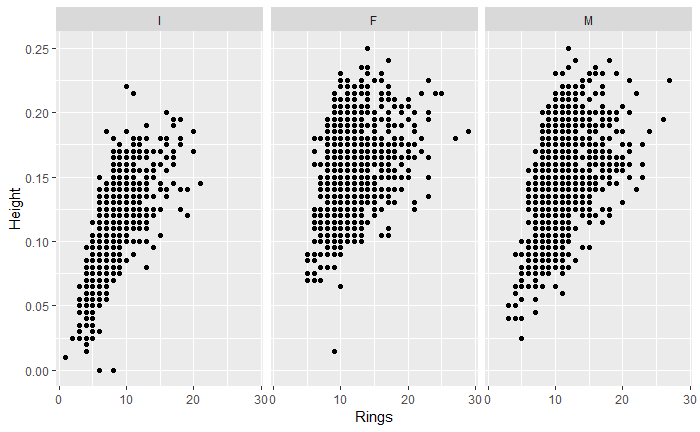

```r
ggplot(data = abalone_error, mapping = aes(x = Rings, y = Height)) +
  geom_point() +
  facet_wrap("Type")
```

Description for chunk 3: Overall males and females are larger than immature abalone for the same number of rings. Overall the females tend to be slightly bigger with neither gender truely becoming totally seperate in size from immature specimens.

Chunk 4

```r
filter(abalone_error, Height == 0)
```

[output not shown]

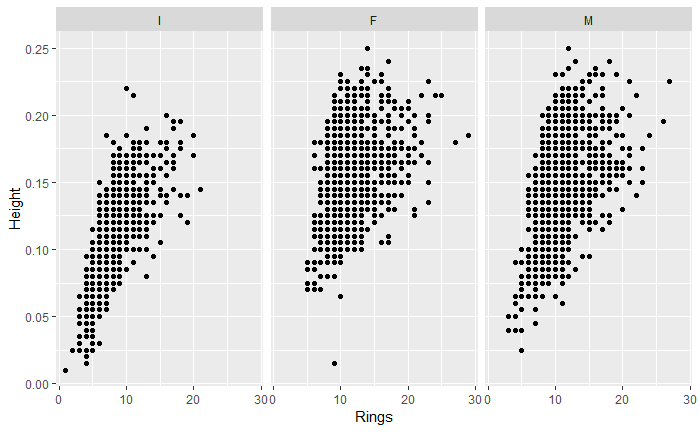

```r
abalone_error[abalone_error == 0] <- NA
ggplot(data = abalone_error, mapping = aes(x = Rings, y = Height)) +
  geom_point() +
  facet_wrap("Type")
```

Chunk 5

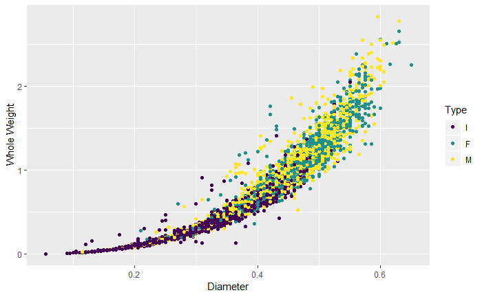

```r
ggplot(data = abalone_error, mapping = aes(x = Diameter, y = WholeWeight)) +
  geom_point(mapping = aes(color = Type)) +
  ylab("Whole Weight")
```

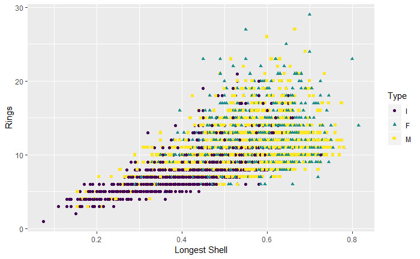

```r
ggplot(data = abalone_error, mapping = aes(x = LongestShell, y = Rings)) +
  geom_point(mapping = aes(color = Type, shape = Type)) +
  xlab("Longest Shell")
```